# 003 ICU

Katie Gostic

11/1/2017

Notes on data formatting from Deborah Wentworth:

- symdur is symptom duration (days) prior to enrollment
- date info is for enrollment date
- fluvac6 and fluvac12 are flu vaccination in last 6 or last 12 months
- anyvac combines values from fluvac6 and fluvac12, whichever was collected for a given patient is reported.
- anyav is use of antivirals at any time
- anydx is any diagnosis in the medical history section
- flutype is subtype: 1=H1N1, 2=H3N2, 3=flu B, 4=PCR negative, 5=Inf A, subtype unknown, and 6=coinfection with multiple strains
- resolved is symptom resolution within 14 days
- country code is the 3 letter code for country of enrollment - think the abbreviations will be obvious

#### Visualize the relationship between age and prob of H1N1 infection

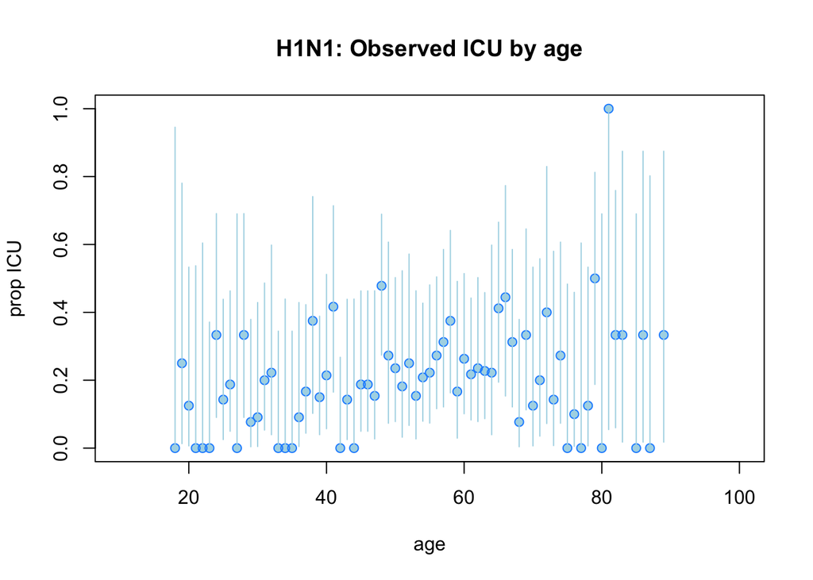

#### Visualize the relationship between age and prob of H3N2 infection

[figure not shown]

#### Visualize the relationship between country and prolonged symptoms

H1N1

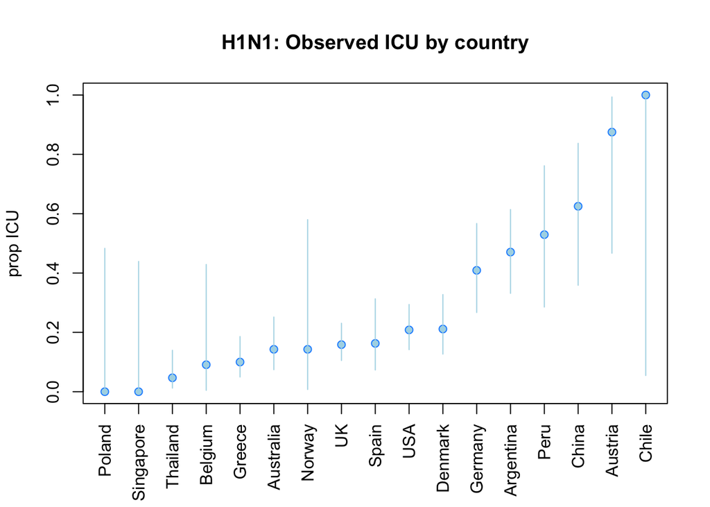

H3N2

[figure not shown]

#### Visualize the relationship between season and prob infection

H1N1

[figure not shown]

H3N2

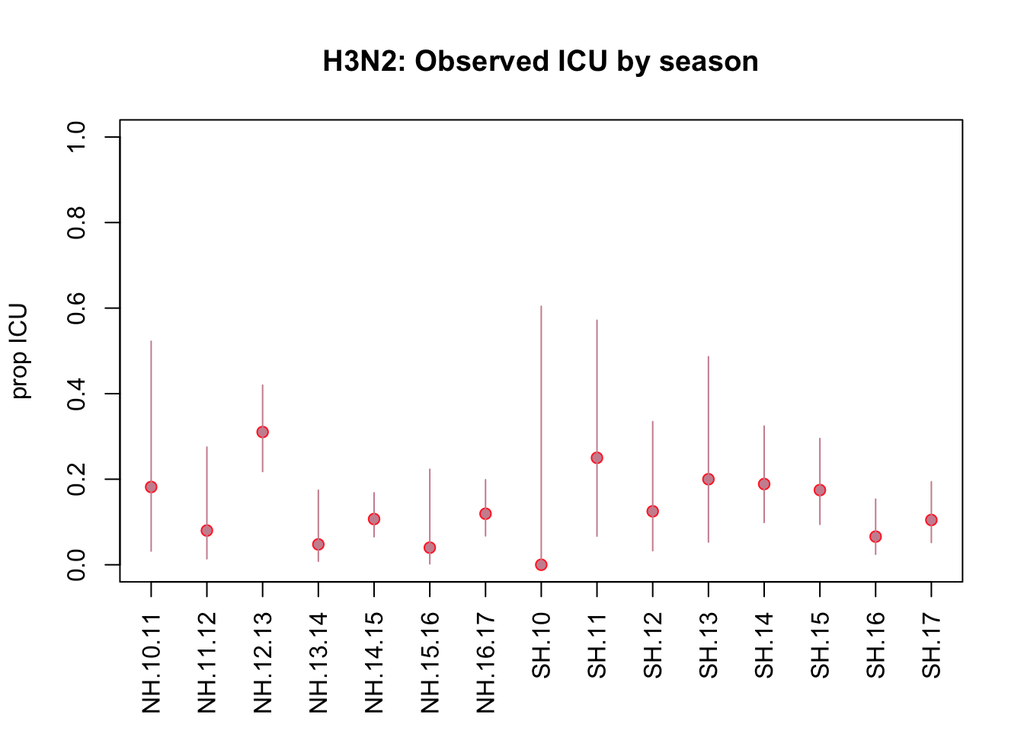

## Set up a logistic regression that includes the following predictors:

- age
- imprinting status
- vaccination status
- antiviral use
- season
- country

### Clean data for fitting

```
##
## Argentina Australia   Austria   Belgium     Chile     China   Denmark
##        51        70         8        11         1        16        71
##   Germany    Greece    Norway      Peru    Poland Singapore     Spain
##        44        90         7        17         6         7        43
##  Thailand        UK       USA
##        64       145       120
```

```
## [1] 771
```

```
##
## Argentina Australia   Belgium     China   Denmark   Germany    Greece
##       117       123         5         7        32        21        24
##      Peru Singapore     Spain  Thailand        UK       USA
##         9        24        31       125        93       180
```

```
## [1] 791
```

### First fit a model where the only independent variable is age

Treat vaccination, antivial use, underlying symptoms, country and season as blocking variables with fixed effects

```r
library(splines)
## H1N1 fit to country, season and medical history only (no effect of age or imprinting)
fit0 = glm(anyicu ~ anyav + anydx + country + H3.valid*season + H3.valid*anyvac, data = train, family = binomial)
summary(fit0)
```

```
##
## Call:
## glm(formula = anyicu ~ anyav + anydx + country + H3.valid * season +
##     H3.valid * anyvac, family = binomial, data = train)
##
## Deviance Residuals:
##     Min       1Q   Median       3Q      Max
## -1.2156  -0.5888  -0.4417  -0.2447   2.9077
##
## Coefficients: (1 not defined because of singularities)
##                            Estimate Std. Error z value Pr(>|z|)
## (Intercept)                 0.02549    0.61414   0.042 0.966892
## anyav1                      0.28825    0.22548   1.278 0.201107
## anydx1                      0.43407    0.23812   1.823 0.068317 .
## countryAustralia           -1.99308    0.45953  -4.337 1.44e-05 ***
## countryDenmark             -2.16542    0.58336  -3.712 0.000206 ***
## countryGermany             -1.28228    0.61744  -2.077 0.037822 *
## countryGreece              -3.25155    0.71679  -4.536 5.73e-06 ***
## countryOther               -1.31064    0.50446  -2.598 0.009374 **
## countryPeru                 1.18198    0.86332   1.369 0.170961
## countrySpain               -2.08014    0.64179  -3.241 0.001191 **
## countryThailand            -3.23779    0.57099  -5.670 1.42e-08 ***
## countryUK                  -1.74811    0.51738  -3.379 0.000728 ***
## countryUSA                 -1.63978    0.51032  -3.213 0.001312 **
## H3.valid1                  13.24620 1013.03593   0.013 0.989567
## seasonNH.10.11              0.43259    0.37527   1.153 0.249015
## seasonNH.11.12             -0.87811    1.23821  -0.709 0.478214
## seasonNH.12.13              0.33032    0.68980   0.479 0.632029
## seasonNH.13.14             -0.26107    0.41489  -0.629 0.529185
## seasonNH.14.15              0.85153    0.69804   1.220 0.222507
## seasonNH.15.16             -0.55558    0.41417  -1.341 0.179779
## seasonNH.16.17            -14.83624  857.69153  -0.017 0.986199
## seasonSH.10                 0.73252    0.83958   0.872 0.382944
## seasonSH.11                 0.06279    0.76970   0.082 0.934982
## seasonSH.12                -2.80460    1.45061  -1.933 0.053187 .
## seasonSH.13                -2.32308    1.01999  -2.278 0.022753 *
## seasonSH.14                -1.02037    1.39927  -0.729 0.465872
## seasonSH.15                -0.72270    1.04060  -0.695 0.487368
## seasonSH.16                -0.66424    0.56707  -1.171 0.241463
## seasonSH.17               -15.45412 1013.03584  -0.015 0.987829
```

[output cut: 13 more lines]

```
## H3.valid1:seasonSH.15     -13.41314 1013.03642  -0.013 0.989436
## H3.valid1:seasonSH.16     -13.53044 1013.03622  -0.013 0.989344
## H3.valid1:seasonSH.17            NA         NA      NA       NA
## H3.valid1:anyvac1           0.15645    0.36959   0.423 0.672069
## ---
## Signif. codes:  0 '***' 0.001 '**' 0.01 '*' 0.05 '.' 0.1 ' ' 1
##
## (Dispersion parameter for binomial family taken to be 1)
##
##     Null deviance: 1182.0  on 1344  degrees of freedom
## Residual deviance: 1020.5  on 1300  degrees of freedom
##   (61 observations deleted due to missingness)
## AIC: 1110.5
##
## Number of Fisher Scoring iterations: 15
```

```r
## H1N1 fit to age only, plus fixed effects of vaccination, av use, underlying conditions, country and season
fit1 = glm(anyicu ~ ns(age,knots = 65) + anyav + anydx + country + H3.valid*season + H3.valid*anyvac, data = train, family = binomial)
summary(fit1)
```

```
##
## Call:
## glm(formula = anyicu ~ ns(age, knots = 65) + anyav + anydx +
##     country + H3.valid * season + H3.valid * anyvac, family = binomial,
##     data = train)
##
## Deviance Residuals:
##     Min       1Q   Median       3Q      Max
## -1.2705  -0.5975  -0.4250  -0.2412   2.9091
##
## Coefficients: (1 not defined because of singularities)
##                            Estimate Std. Error z value Pr(>|z|)
## (Intercept)                -0.40720    0.65784  -0.619 0.535921
## ns(age, knots = 65)1        1.07200    0.63023   1.701 0.088949 .
## ns(age, knots = 65)2       -0.57777    0.47488  -1.217 0.223727
## anyav1                      0.27816    0.22618   1.230 0.218771
## anydx1                      0.35439    0.24570   1.442 0.149204
## countryAustralia           -2.02219    0.46070  -4.389 1.14e-05 ***
## countryDenmark             -2.16166    0.58703  -3.682 0.000231 ***
## countryGermany             -1.21266    0.62261  -1.948 0.051452 .
## countryGreece              -3.32307    0.71820  -4.627 3.71e-06 ***
## countryOther               -1.36820    0.50635  -2.702 0.006891 **
## countryPeru                 1.17897    0.87318   1.350 0.176954
## countrySpain               -2.12609    0.64371  -3.303 0.000957 ***
## countryThailand            -3.24829    0.57183  -5.681 1.34e-08 ***
## countryUK                  -1.75849    0.52498  -3.350 0.000809 ***
## countryUSA                 -1.67072    0.51626  -3.236 0.001211 **
## H3.valid1                  13.36394 1012.99950   0.013 0.989474
## seasonNH.10.11              0.37474    0.37745   0.993 0.320807
## seasonNH.11.12             -0.69991    1.22575  -0.571 0.567998
## seasonNH.12.13              0.21966    0.69243   0.317 0.751069
## seasonNH.13.14             -0.29810    0.41755  -0.714 0.475278
## seasonNH.14.15              0.86044    0.70659   1.218 0.223325
## seasonNH.15.16             -0.62952    0.41769  -1.507 0.131779
## seasonNH.16.17            -14.93215  847.09725  -0.018 0.985936
## seasonSH.10                 0.81332    0.84500   0.963 0.335796
## seasonSH.11                 0.09764    0.77103   0.127 0.899227
## seasonSH.12                -2.65255    1.45493  -1.823 0.068281 .
## seasonSH.13                -2.26213    1.00779  -2.245 0.024791 *
## seasonSH.14                -1.06353    1.40375  -0.758 0.448670
```

[output cut: 16 more lines]

```
## H3.valid1:seasonSH.15     -13.35296 1013.00000  -0.013 0.989483
## H3.valid1:seasonSH.16     -13.56373 1012.99979  -0.013 0.989317
## H3.valid1:seasonSH.17            NA         NA      NA       NA
## H3.valid1:anyvac1           0.19651    0.37103   0.530 0.596368
## ---
## Signif. codes:  0 '***' 0.001 '**' 0.01 '*' 0.05 '.' 0.1 ' ' 1
##
## (Dispersion parameter for binomial family taken to be 1)
##
##     Null deviance: 1182.0  on 1344  degrees of freedom
## Residual deviance: 1015.7  on 1298  degrees of freedom
##   (61 observations deleted due to missingness)
## AIC: 1109.7
##
## Number of Fisher Scoring iterations: 15
```

```r
## H1N1 fit to age plus imprinting, plus fixed effects of vaccination, av use, underlying conditions, country and season
fit2 = glm(anyicu ~ ns(age, knots = 65) + p.protected + anyav + anydx + country + H3.valid*season + H3.valid*anyvac, data = train, family = binomial)
summary(fit2)
```

```
##
## Call:
## glm(formula = anyicu ~ ns(age, knots = 65) + p.protected + anyav +
##     anydx + country + H3.valid * season + H3.valid * anyvac,
##     family = binomial, data = train)
##
## Deviance Residuals:
##     Min       1Q   Median       3Q      Max
## -1.2837  -0.5935  -0.4244  -0.2379   2.8692
##
## Coefficients: (1 not defined because of singularities)
##                           Estimate Std. Error z value Pr(>|z|)
## (Intercept)                -0.4739     0.6652  -0.712 0.476178
## ns(age, knots = 65)1        1.0030     0.6320   1.587 0.112489
## ns(age, knots = 65)2       -0.5350     0.4778  -1.120 0.262839
## p.protected                 0.1736     0.2353   0.738 0.460790
## anyav1                      0.2841     0.2264   1.255 0.209536
## anydx1                      0.3460     0.2459   1.407 0.159463
## countryAustralia           -2.0231     0.4616  -4.383 1.17e-05 ***
## countryDenmark             -2.1511     0.5869  -3.665 0.000247 ***
## countryGermany             -1.1934     0.6232  -1.915 0.055505 .
## countryGreece              -3.3519     0.7197  -4.657 3.20e-06 ***
## countryOther               -1.3613     0.5066  -2.687 0.007204 **
## countryPeru                 1.1809     0.8760   1.348 0.177646
## countrySpain               -2.1157     0.6442  -3.284 0.001022 **
## countryThailand            -3.2490     0.5722  -5.678 1.36e-08 ***
## countryUK                  -1.7640     0.5256  -3.356 0.000791 ***
## countryUSA                 -1.6859     0.5172  -3.259 0.001116 **
## H3.valid1                  13.4607  1011.3627   0.013 0.989381
## seasonNH.10.11              0.3578     0.3786   0.945 0.344617
## seasonNH.11.12             -0.6926     1.2236  -0.566 0.571349
## seasonNH.12.13              0.2033     0.6950   0.293 0.769885
## seasonNH.13.14             -0.2859     0.4183  -0.683 0.494386
## seasonNH.14.15              0.8547     0.7074   1.208 0.226982
## seasonNH.15.16             -0.6277     0.4178  -1.502 0.132998
## seasonNH.16.17            -14.9508   846.5915  -0.018 0.985910
## seasonSH.10                 0.8202     0.8461   0.969 0.332347
## seasonSH.11                 0.1127     0.7726   0.146 0.883997
## seasonSH.12                -2.6508     1.4561  -1.820 0.068687 .
## seasonSH.13                -2.2518     1.0089  -2.232 0.025616 *
```

[output cut: 17 more lines]

```
## H3.valid1:seasonSH.15     -13.3514  1011.3632  -0.013 0.989467
## H3.valid1:seasonSH.16     -13.5746  1011.3630  -0.013 0.989291
## H3.valid1:seasonSH.17           NA         NA      NA       NA
## H3.valid1:anyvac1           0.2399     0.3755   0.639 0.522841
## ---
## Signif. codes:  0 '***' 0.001 '**' 0.01 '*' 0.05 '.' 0.1 ' ' 1
##
## (Dispersion parameter for binomial family taken to be 1)
##
##     Null deviance: 1182.0  on 1344  degrees of freedom
## Residual deviance: 1015.1  on 1297  degrees of freedom
##   (61 observations deleted due to missingness)
## AIC: 1111.1
##
## Number of Fisher Scoring iterations: 15
```

```r
# Add imprinting at H.subtype level
fit3 = glm(anyicu ~ anyav + anydx + country + ns(age, knots = 65) + p.H.subtype + H3.valid*season + H3.valid*anyvac, data = train, family = binomial)
summary(fit3)
```

```
##
## Call:
## glm(formula = anyicu ~ anyav + anydx + country + ns(age, knots = 65) +
##     p.H.subtype + H3.valid * season + H3.valid * anyvac, family = binomial,
##     data = train)
##
## Deviance Residuals:
##     Min       1Q   Median       3Q      Max
## -1.3190  -0.5933  -0.4276  -0.2362   2.8647
##
## Coefficients: (1 not defined because of singularities)
##                           Estimate Std. Error z value Pr(>|z|)
## (Intercept)                -0.5497     0.6654  -0.826 0.408778
## anyav1                      0.2978     0.2270   1.312 0.189656
## anydx1                      0.3408     0.2462   1.384 0.166311
## countryAustralia           -2.0190     0.4632  -4.359 1.31e-05 ***
## countryDenmark             -2.1783     0.5869  -3.711 0.000206 ***
## countryGermany             -1.1986     0.6229  -1.924 0.054312 .
## countryGreece              -3.4158     0.7227  -4.727 2.28e-06 ***
## countryOther               -1.3829     0.5078  -2.723 0.006466 **
## countryPeru                 1.1586     0.8778   1.320 0.186849
## countrySpain               -2.1554     0.6451  -3.341 0.000834 ***
## countryThailand            -3.2863     0.5754  -5.711 1.12e-08 ***
## countryUK                  -1.7927     0.5271  -3.401 0.000671 ***
## countryUSA                 -1.7222     0.5188  -3.319 0.000902 ***
## ns(age, knots = 65)1        1.1142     0.6234   1.787 0.073881 .
## ns(age, knots = 65)2       -0.6190     0.4769  -1.298 0.194310
## p.H.subtype                 0.3688     0.2238   1.648 0.099322 .
## H3.valid1                  13.4175  1014.2904   0.013 0.989445
## seasonNH.10.11              0.3562     0.3787   0.941 0.346956
## seasonNH.11.12             -0.6438     1.2266  -0.525 0.599695
## seasonNH.12.13              0.2848     0.6957   0.409 0.682255
## seasonNH.13.14             -0.2470     0.4195  -0.589 0.556086
## seasonNH.14.15              0.8318     0.7075   1.176 0.239686
## seasonNH.15.16             -0.6122     0.4179  -1.465 0.142904
## seasonNH.16.17            -14.8696   853.9575  -0.017 0.986107
## seasonSH.10                 0.7920     0.8465   0.936 0.349445
## seasonSH.11                 0.1051     0.7729   0.136 0.891840
## seasonSH.12                -2.6883     1.4562  -1.846 0.064878 .
## seasonSH.13                -2.2509     1.0111  -2.226 0.025995 *
```

[output cut: 17 more lines]

```
## H3.valid1:seasonSH.15     -13.2996  1014.2909  -0.013 0.989538
## H3.valid1:seasonSH.16     -13.5074  1014.2907  -0.013 0.989375
## H3.valid1:seasonSH.17           NA         NA      NA       NA
## H3.valid1:anyvac1           0.3090     0.3776   0.818 0.413142
## ---
## Signif. codes:  0 '***' 0.001 '**' 0.01 '*' 0.05 '.' 0.1 ' ' 1
##
## (Dispersion parameter for binomial family taken to be 1)
##
##     Null deviance: 1182  on 1344  degrees of freedom
## Residual deviance: 1013  on 1297  degrees of freedom
##   (61 observations deleted due to missingness)
## AIC: 1109
##
## Number of Fisher Scoring iterations: 15
```

```r
# Add imprinting at N.subtype level
fit4 = glm(anyicu ~ anyav + anydx + country + ns(age, knots = 65) + p.N.subtype + H3.valid*season + H3.valid*anyvac, data = train, family = binomial)
summary(fit4)
```

```
##
## Call:
## glm(formula = anyicu ~ anyav + anydx + country + ns(age, knots = 65) +
##     p.N.subtype + H3.valid * season + H3.valid * anyvac, family = binomial,
##     data = train)
##
## Deviance Residuals:
##     Min       1Q   Median       3Q      Max
## -1.3300  -0.5966  -0.4254  -0.2321   2.8663
##
## Coefficients: (1 not defined because of singularities)
##                            Estimate Std. Error z value Pr(>|z|)
## (Intercept)                -0.48099    0.65967  -0.729 0.465919
## anyav1                      0.29354    0.22705   1.293 0.196076
## anydx1                      0.33775    0.24629   1.371 0.170266
## countryAustralia           -2.00382    0.46364  -4.322 1.55e-05 ***
## countryDenmark             -2.18187    0.58823  -3.709 0.000208 ***
## countryGermany             -1.22161    0.62362  -1.959 0.050125 .
## countryGreece              -3.45489    0.72444  -4.769 1.85e-06 ***
## countryOther               -1.40002    0.50921  -2.749 0.005970 **
## countryPeru                 1.14370    0.87784   1.303 0.192622
## countrySpain               -2.17798    0.64643  -3.369 0.000754 ***
## countryThailand            -3.29974    0.57662  -5.723 1.05e-08 ***
## countryUK                  -1.81402    0.52890  -3.430 0.000604 ***
## countryUSA                 -1.75236    0.52108  -3.363 0.000771 ***
## ns(age, knots = 65)1        1.03127    0.62335   1.654 0.098044 .
## ns(age, knots = 65)2       -0.40560    0.47937  -0.846 0.397494
## p.N.subtype                 0.44811    0.20753   2.159 0.030830 *
## H3.valid1                  13.29658 1014.80201   0.013 0.989546
## seasonNH.10.11              0.35662    0.37885   0.941 0.346531
## seasonNH.11.12             -0.66296    1.23044  -0.539 0.590025
## seasonNH.12.13              0.31449    0.69628   0.452 0.651512
## seasonNH.13.14             -0.23100    0.41949  -0.551 0.581863
## seasonNH.14.15              0.80055    0.70644   1.133 0.257120
## seasonNH.15.16             -0.60949    0.41801  -1.458 0.144817
## seasonNH.16.17            -14.85006  858.15214  -0.017 0.986194
## seasonSH.10                 0.76008    0.84708   0.897 0.369566
## seasonSH.11                 0.07712    0.77340   0.100 0.920571
## seasonSH.12                -2.72397    1.45571  -1.871 0.061313 .
## seasonSH.13                -2.26994    1.01362  -2.239 0.025128 *
```

[output cut: 17 more lines]

```
## H3.valid1:seasonSH.15     -13.27030 1014.80250  -0.013 0.989567
## H3.valid1:seasonSH.16     -13.47362 1014.80231  -0.013 0.989407
## H3.valid1:seasonSH.17            NA         NA      NA       NA
## H3.valid1:anyvac1           0.33925    0.37794   0.898 0.369385
## ---
## Signif. codes:  0 '***' 0.001 '**' 0.01 '*' 0.05 '.' 0.1 ' ' 1
##
## (Dispersion parameter for binomial family taken to be 1)
##
##     Null deviance: 1182  on 1344  degrees of freedom
## Residual deviance: 1011  on 1297  degrees of freedom
##   (61 observations deleted due to missingness)
## AIC: 1107
##
## Number of Fisher Scoring iterations: 15
```

```r
par(mfrow = c(1, 2), las = 3, mar = c(6, 6, 6, 3), cex.axis = .7)
library(gam)
```

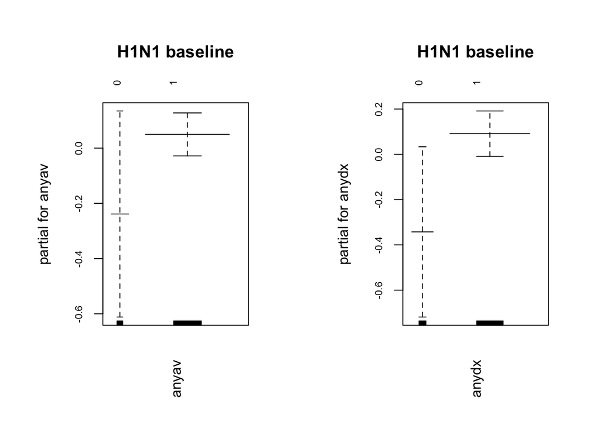

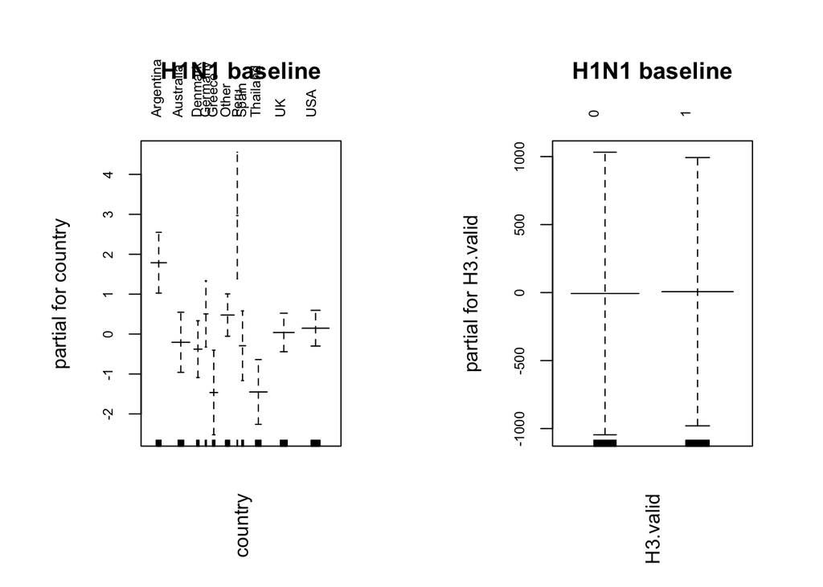

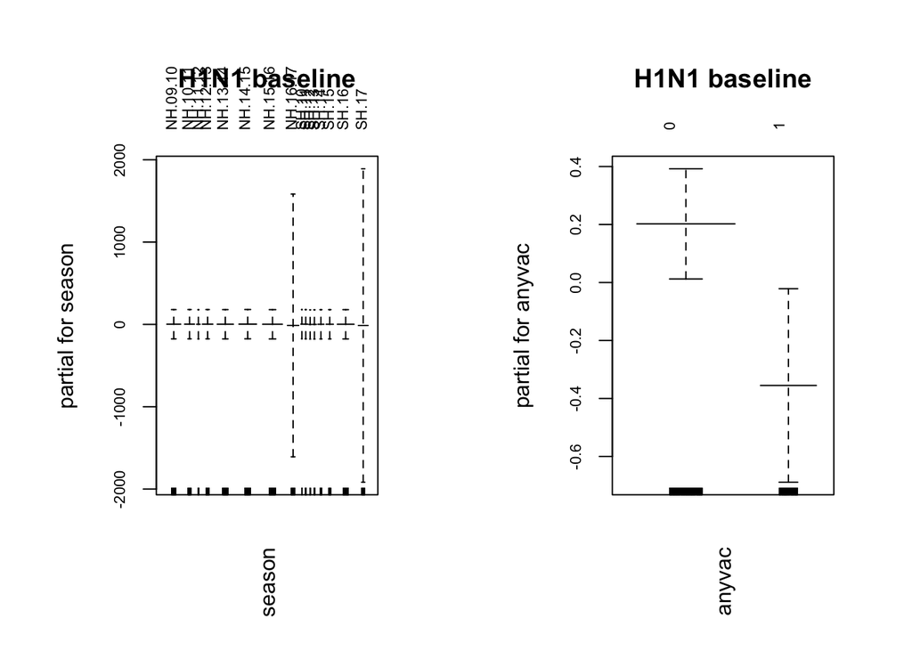

```r
plot.gam(fit0, se = T, col = 'darkslateblue', main = 'H1N1 baseline')
```

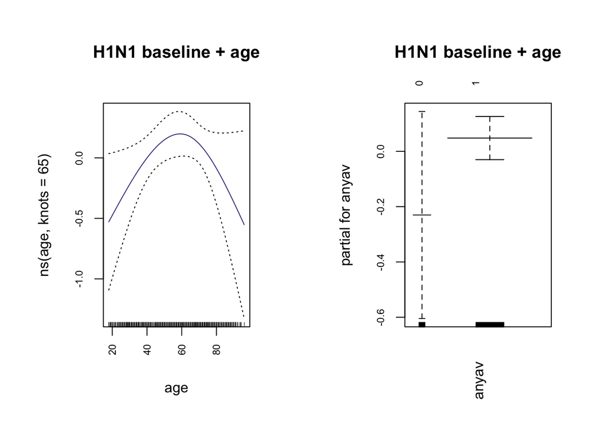

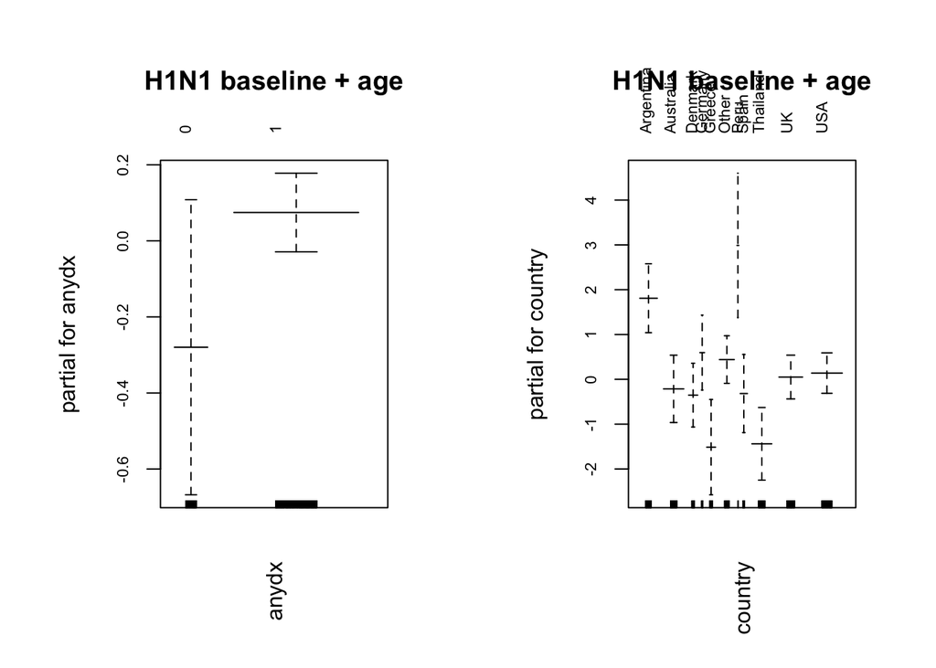

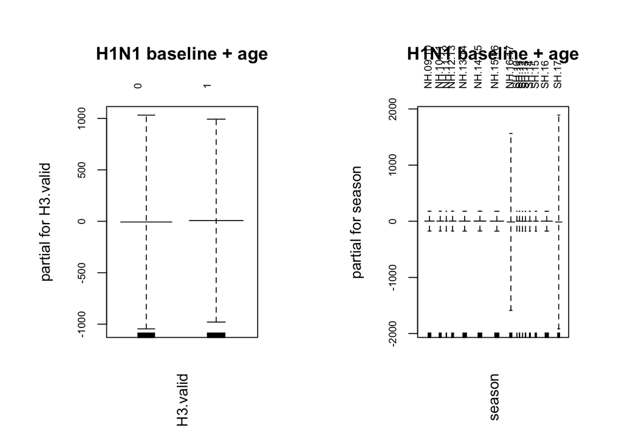

```r
plot.gam(fit1, se = T, col = 'darkslateblue', main = 'H1N1 baseline + age')
```

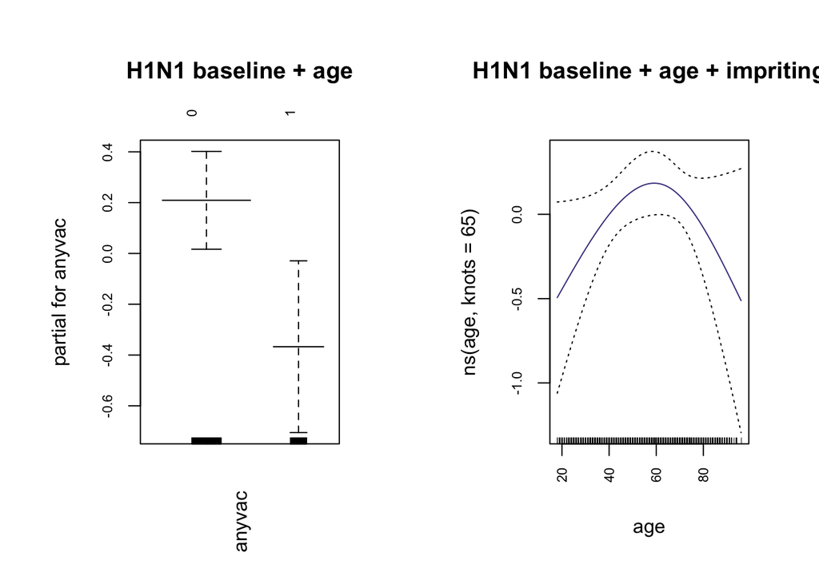

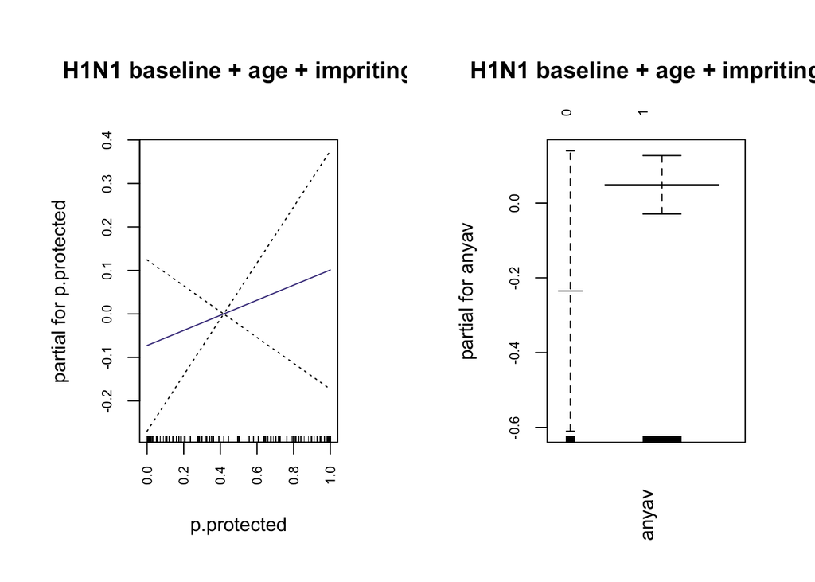

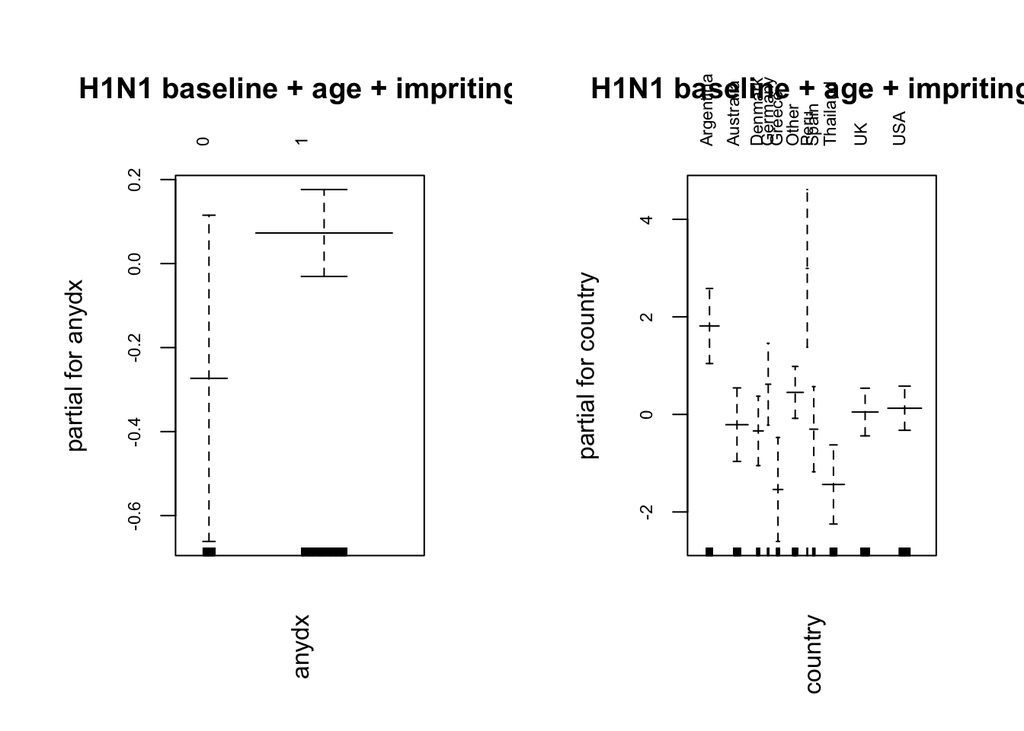

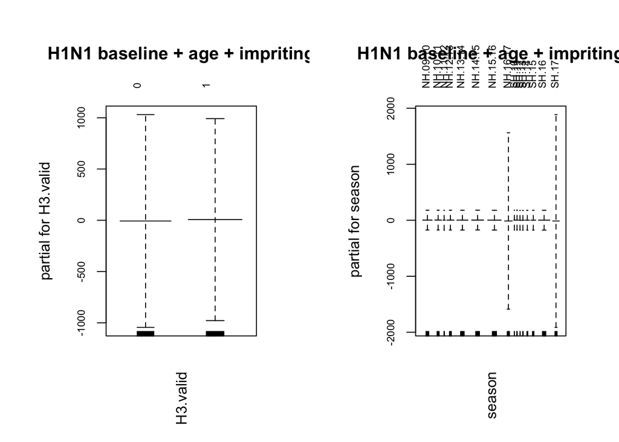

```r
plot.gam(fit2, se = T, col = 'darkslateblue', main = 'H1N1 baseline + age + impriting')
```

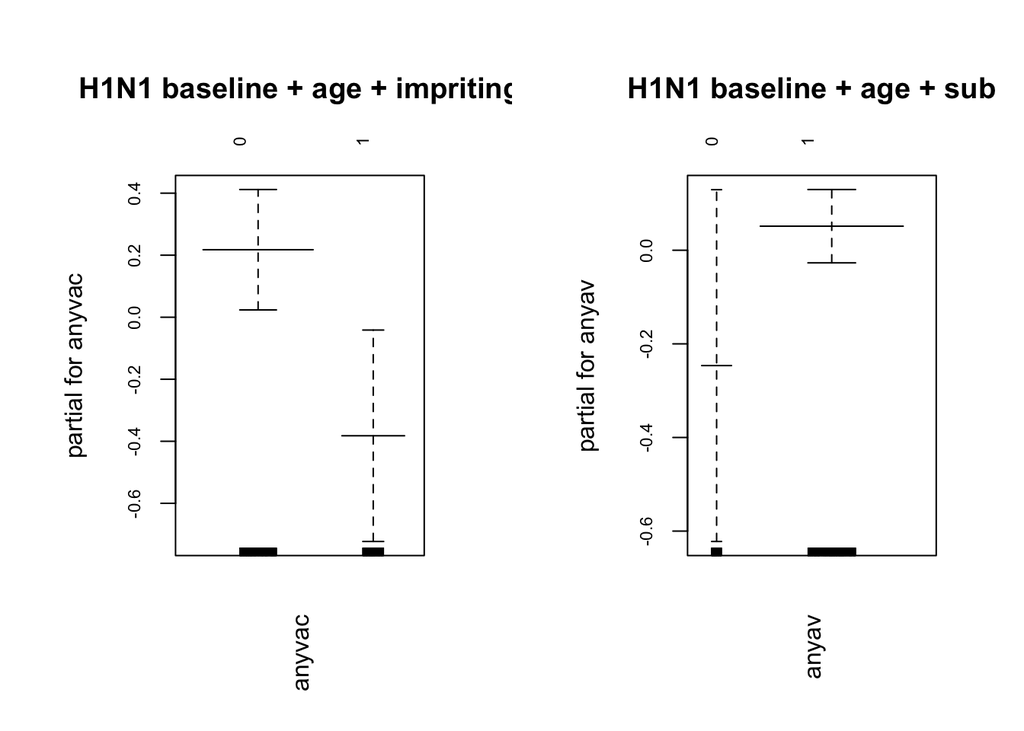

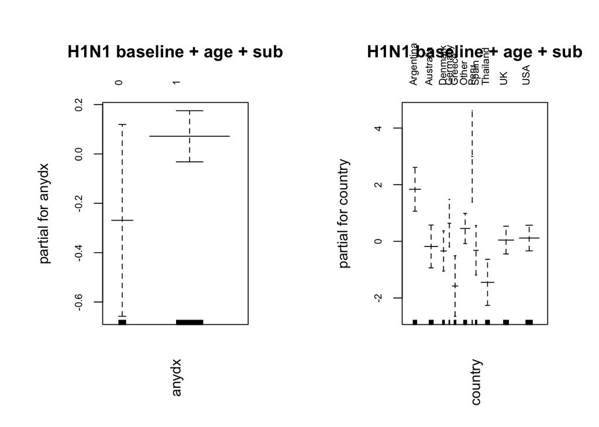

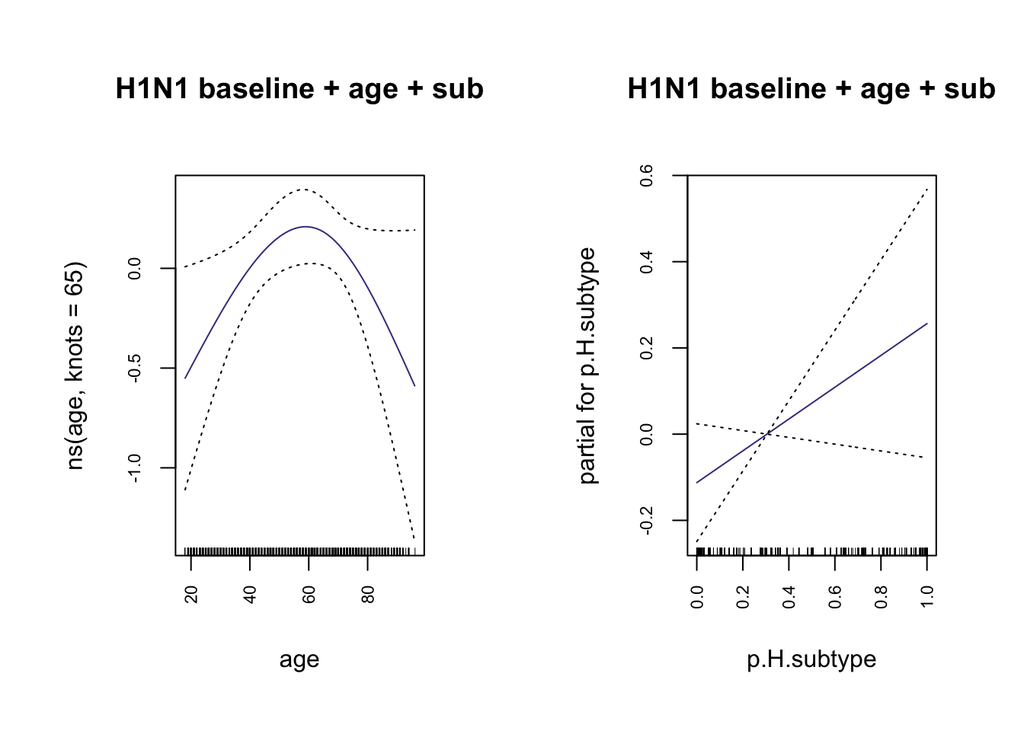

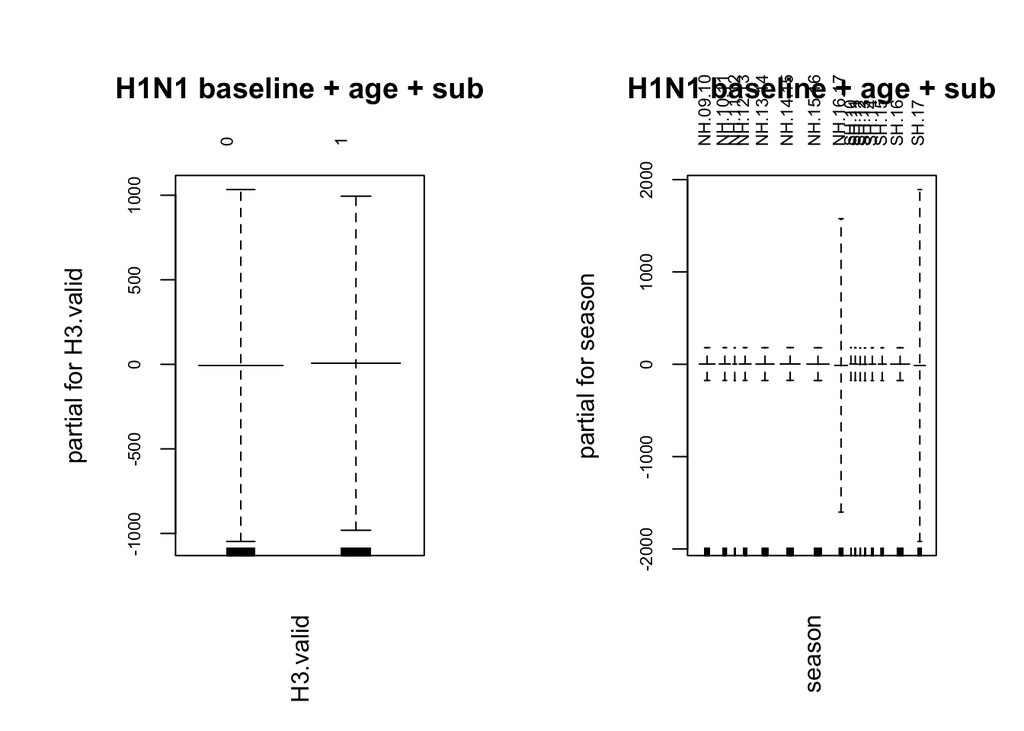

```r
plot.gam(fit3, se = T, col = 'darkslateblue', main = 'H1N1 baseline + age + sub')
```

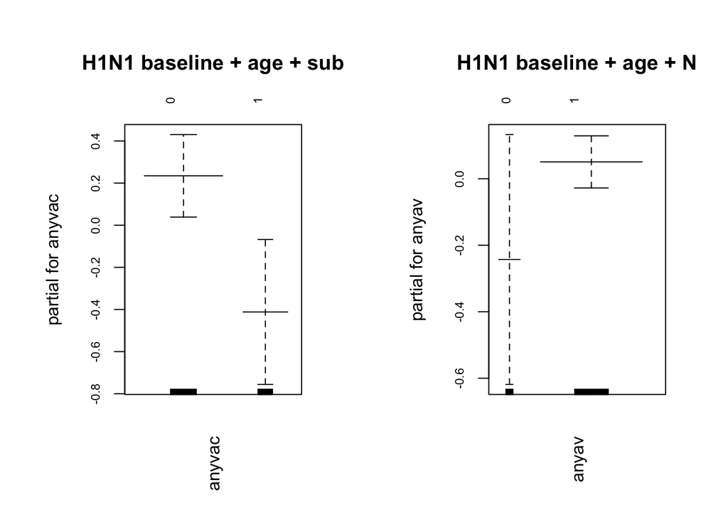

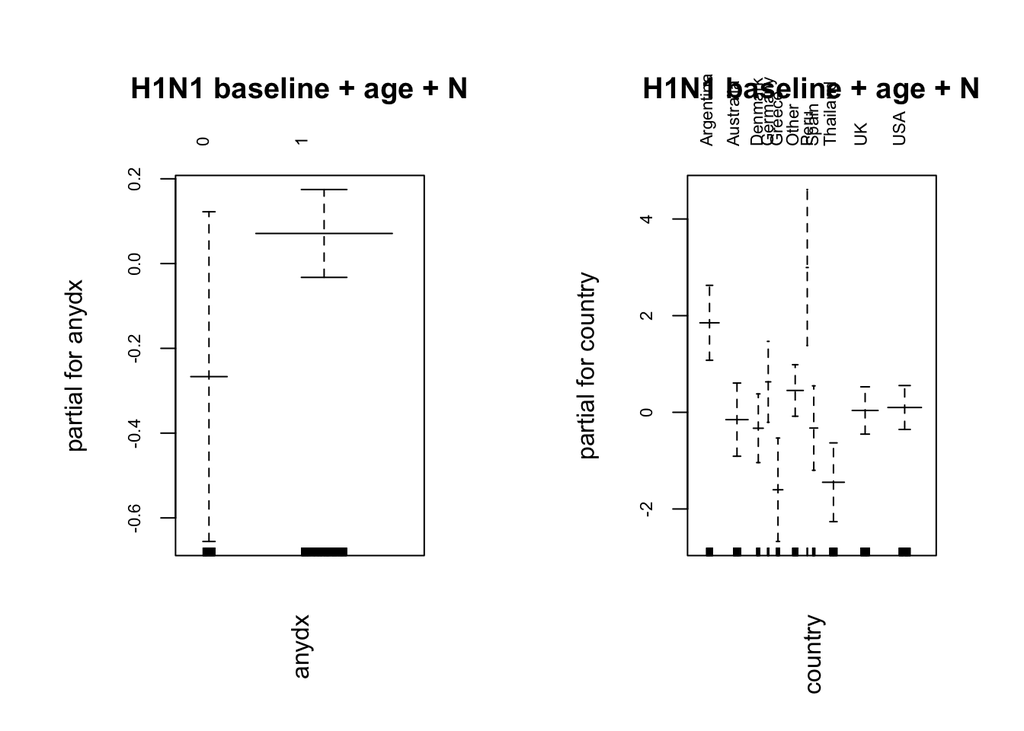

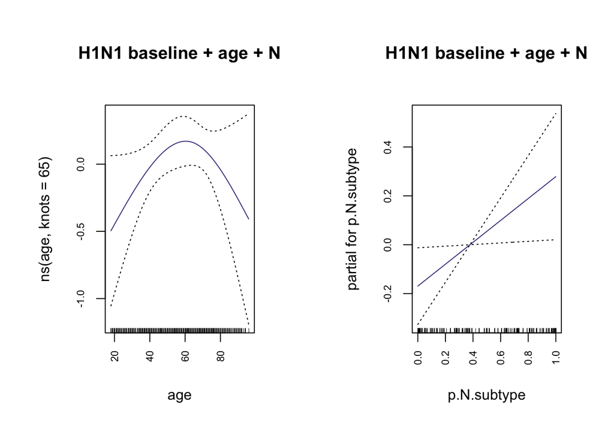

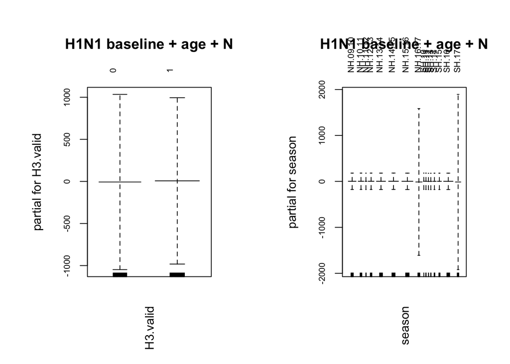

```r
plot.gam(fit4, se = T, col = 'darkslateblue', main = 'H1N1 baseline + age + N')
```

```r
pdf('003ICU_constrained.pdf')
plot.gam(fit2, se = T, col = 'darkslateblue', main = 'H1N1 baseline + age + impriting')
dev.off()
```

```r
# Predict probs for each patient
probs0 = predict(fit0, newdata = test, type = 'response')
probs1 = predict(fit1, newdata = test, type = 'response')
probs2 = predict(fit2, newdata = test, type = 'response')
probs3 = predict(fit3, newdata = test, type = 'response')
probs4 = predict(fit4, newdata = test, type = 'response')
```

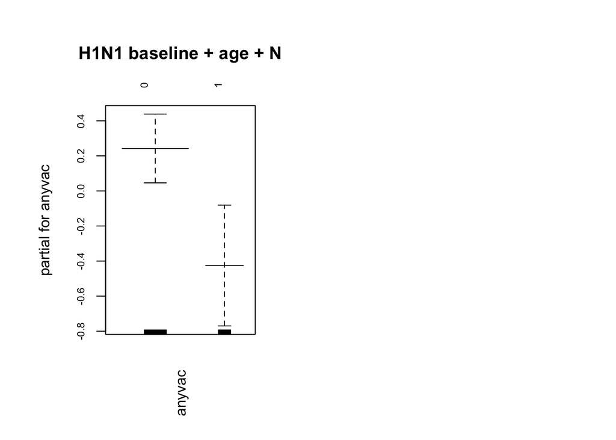

```r
# Create a predict object
pr0 = prediction(probs0, test$anyicu)
pr1 = prediction(probs1, test$anyicu)
pr2 = prediction(probs2, test$anyicu)
pr3 = prediction(probs3, test$anyicu)
pr4 = prediction(probs4, test$anyicu)

# Assess tp and fp
prf0 = performance(pr0, measure = 'tpr', x.measure = 'fpr')
prf1 = performance(pr1, measure = 'tpr', x.measure = 'fpr')
prf2 = performance(pr2, measure = 'tpr', x.measure = 'fpr')
prf3 = performance(pr3, measure = 'tpr', x.measure = 'fpr')
prf4 = performance(pr4, measure = 'tpr', x.measure = 'fpr')

# Calculate AUCs
auc = sapply(list(pr0, pr1, pr2, pr3, pr4), FUN = function(xx){aa = performance(xx, measure = 'auc')
                                                                      round(aa@y.values[[1]], 3) })

# Plot AUC
par(mfrow = c(1,1))
```

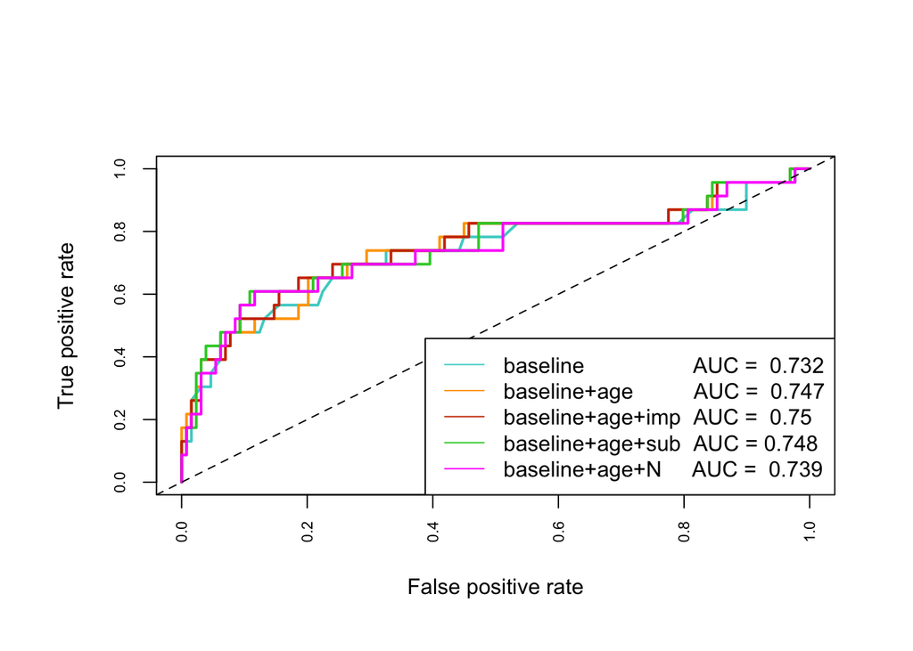

```r
plot(prf0, lwd = 2, col = cols[3])
plot(prf1, col = cols[2], add = TRUE, lwd = 2)
plot(prf2, col = cols[1], add = TRUE, lwd = 2)
plot(prf3, col = 'limegreen', add = TRUE, lwd = 2)
plot(prf4, col = 'magenta', add = TRUE, lwd = 2)
abline(a = 0, b = 1, lty = 2)
legend('bottomright', paste(c('baseline                  AUC = ', 'baseline+age          AUC = ', 'baseline+age+imp  AUC = ', 'baseline+age+sub  AUC =', 'baseline+age+N     AUC = '), auc), col = c(cols[3:1], 'limegreen', 'magenta'),  lty = 1)
```

```r
pdf('003ICU_AUC_constrained.pdf')
par(lwd = 3.5, cex = 1.5, cex.axis = 1.5, cex.lab = 1.5)
# Plot AUC
par(mfrow = c(1,1))
plot(prf0, col = cols[3])
plot(prf1, col = cols[2], add = TRUE)
plot(prf2, col = cols[1], add = TRUE)
plot(prf3, col = 'limegreen', add = TRUE, lwd = 2)
plot(prf4, col = 'magenta', add = TRUE, lwd = 2)
abline(a = 0, b = 1, lty = 2)
legend('bottomright', paste(c('baseline                  AUC = ', 'baseline+age          AUC = ', 'baseline+age+imp  AUC = ', 'baseline+age+sub  AUC =', 'baseline+age+N     AUC = '), auc), col = c(cols[3:1], 'limegreen', 'magenta'),  lty = 1)
dev.off()
```

```r
# Calculate AUC for test data
AIC = c(fit0$aic, fit1$aic, fit2$aic, fit3$aic, fit4$aic); names(AIC) =  c('baseline', 'baseline+age', 'baseline+age+imp', 'baseline+age+sub', 'baseline+age+N')
del.AIC = sort(AIC - min(AIC))
del.AIC
```

```
##   baseline+age+N baseline+age+sub     baseline+age         baseline
##         0.000000         1.965772         2.655638         3.508896
## baseline+age+imp
##         4.112931
```

```r
load('master.AIC.table.constrained.RData')
master.AIC.table['003ICU', c('baseline', 'baseline+age', 'baseline+age+imp', 'baseline+age+sub', 'baseline+age+N')] = AIC - min(AIC)
save(master.AIC.table, file = 'master.AIC.table.constrained.RData')
rm(master.AIC.table)
```